# Risk Factor Analysis

## Outcome Variable

**Outcome Variable:** sstunted

## Predictor Variables

**Intervention Variable:** mwtkg

**Adjustment Set:**

- arm
- W_mage
- meducyrs
- feducyrs
- single
- brthmon
- W_parity
- delta_W_mage
- delta_meducyrs
- delta_feducyrs
- delta_single
- delta_brthmon
- delta_W_parity

## Stratifying Variables

The analysis was stratified on these variable(s):

- agecat
- studyid
- country

## Data Summary

| agecat | studyid | country | mwtkg | sstunted | n_cell | n |
| --- | --- | --- | --- | --- | --- | --- |
| Birth | ki0047075b-MAL-ED | BANGLADESH | >=58 kg | 0 | 38 | 222 |
| Birth | ki0047075b-MAL-ED | BANGLADESH | >=58 kg | 1 | 0 | 222 |
| Birth | ki0047075b-MAL-ED | BANGLADESH | <52 kg | 0 | 136 | 222 |
| Birth | ki0047075b-MAL-ED | BANGLADESH | <52 kg | 1 | 7 | 222 |
| Birth | ki0047075b-MAL-ED | BANGLADESH | [52-58) kg | 0 | 41 | 222 |
| Birth | ki0047075b-MAL-ED | BANGLADESH | [52-58) kg | 1 | 0 | 222 |
| Birth | ki0047075b-MAL-ED | BRAZIL | >=58 kg | 0 | 32 | 64 |
| Birth | ki0047075b-MAL-ED | BRAZIL | >=58 kg | 1 | 2 | 64 |
| Birth | ki0047075b-MAL-ED | BRAZIL | <52 kg | 0 | 15 | 64 |
| Birth | ki0047075b-MAL-ED | BRAZIL | <52 kg | 1 | 0 | 64 |
| Birth | ki0047075b-MAL-ED | BRAZIL | [52-58) kg | 0 | 14 | 64 |
| Birth | ki0047075b-MAL-ED | BRAZIL | [52-58) kg | 1 | 1 | 64 |
| Birth | ki0047075b-MAL-ED | INDIA | >=58 kg | 0 | 6 | 43 |
| Birth | ki0047075b-MAL-ED | INDIA | >=58 kg | 1 | 0 | 43 |
| Birth | ki0047075b-MAL-ED | INDIA | <52 kg | 0 | 28 | 43 |
| Birth | ki0047075b-MAL-ED | INDIA | <52 kg | 1 | 1 | 43 |
| Birth | ki0047075b-MAL-ED | INDIA | [52-58) kg | 0 | 7 | 43 |
| Birth | ki0047075b-MAL-ED | INDIA | [52-58) kg | 1 | 1 | 43 |
| Birth | ki0047075b-MAL-ED | NEPAL | >=58 kg | 0 | 9 | 27 |
| Birth | ki0047075b-MAL-ED | NEPAL | >=58 kg | 1 | 0 | 27 |
| Birth | ki0047075b-MAL-ED | NEPAL | <52 kg | 0 | 7 | 27 |
| Birth | ki0047075b-MAL-ED | NEPAL | <52 kg | 1 | 1 | 27 |
| Birth | ki0047075b-MAL-ED | NEPAL | [52-58) kg | 0 | 10 | 27 |
| Birth | ki0047075b-MAL-ED | NEPAL | [52-58) kg | 1 | 0 | 27 |
| Birth | ki0047075b-MAL-ED | PERU | >=58 kg | 0 | 82 | 226 |
| Birth | ki0047075b-MAL-ED | PERU | >=58 kg | 1 | 1 | 226 |
| Birth | ki0047075b-MAL-ED | PERU | <52 kg | 0 | 81 | 226 |
| Birth | ki0047075b-MAL-ED | PERU | <52 kg | 1 | 3 | 226 |
| Birth | ki0047075b-MAL-ED | PERU | [52-58) kg | 0 | 59 | 226 |
| Birth | ki0047075b-MAL-ED | PERU | [52-58) kg | 1 | 0 | 226 |

[output cut: 240 more lines]

The following strata were considered:

- agecat: 24 months, studyid: ki0047075b-MAL-ED, country: BANGLADESH
- agecat: 24 months, studyid: ki0047075b-MAL-ED, country: BRAZIL
- agecat: 24 months, studyid: ki0047075b-MAL-ED, country: INDIA
- agecat: 24 months, studyid: ki0047075b-MAL-ED, country: NEPAL
- agecat: 24 months, studyid: ki0047075b-MAL-ED, country: PERU
- agecat: 24 months, studyid: ki0047075b-MAL-ED, country: SOUTH AFRICA
- agecat: 24 months, studyid: ki0047075b-MAL-ED, country: TANZANIA, UNITED REPUBLIC OF
- agecat: 24 months, studyid: ki1017093-NIH-Birth, country: BANGLADESH
- agecat: 24 months, studyid: ki1017093b-PROVIDE, country: BANGLADESH
- agecat: 24 months, studyid: ki1017093c-NIH-Crypto, country: BANGLADESH
- agecat: 24 months, studyid: ki1066203-TanzaniaChild2, country: TANZANIA, UNITED REPUBLIC OF
- agecat: 24 months, studyid: ki1119695-PROBIT, country: BELARUS
- agecat: 24 months, studyid: ki1126311-ZVITAMBO, country: ZIMBABWE
- agecat: 24 months, studyid: ki1148112-LCNI-5, country: MALAWI
- agecat: 24 months, studyid: kiGH5241-JiVitA-3, country: BANGLADESH
- agecat: 6 months, studyid: ki0047075b-MAL-ED, country: BANGLADESH
- agecat: 6 months, studyid: ki0047075b-MAL-ED, country: BRAZIL
- agecat: 6 months, studyid: ki0047075b-MAL-ED, country: INDIA
- agecat: 6 months, studyid: ki0047075b-MAL-ED, country: NEPAL
- agecat: 6 months, studyid: ki0047075b-MAL-ED, country: PERU
- agecat: 6 months, studyid: ki0047075b-MAL-ED, country: SOUTH AFRICA
- agecat: 6 months, studyid: ki0047075b-MAL-ED, country: TANZANIA, UNITED REPUBLIC OF
- agecat: 6 months, studyid: ki1000304b-SAS-CompFeed, country: INDIA
- agecat: 6 months, studyid: ki1017093-NIH-Birth, country: BANGLADESH
- agecat: 6 months, studyid: ki1017093b-PROVIDE, country: BANGLADESH
- agecat: 6 months, studyid: ki1017093c-NIH-Crypto, country: BANGLADESH
- agecat: 6 months, studyid: ki1066203-TanzaniaChild2, country: TANZANIA, UNITED REPUBLIC OF
- agecat: 6 months, studyid: ki1119695-PROBIT, country: BELARUS
- agecat: 6 months, studyid: ki1126311-ZVITAMBO, country: ZIMBABWE
- agecat: 6 months, studyid: ki1148112-LCNI-5, country: MALAWI
- agecat: 6 months, studyid: kiGH5241-JiVitA-3, country: BANGLADESH
- agecat: Birth, studyid: ki0047075b-MAL-ED, country: BANGLADESH
- agecat: Birth, studyid: ki0047075b-MAL-ED, country: BRAZIL
- agecat: Birth, studyid: ki0047075b-MAL-ED, country: INDIA
- agecat: Birth, studyid: ki0047075b-MAL-ED, country: NEPAL
- agecat: Birth, studyid: ki0047075b-MAL-ED, country: PERU
- agecat: Birth, studyid: ki0047075b-MAL-ED, country: SOUTH AFRICA
- agecat: Birth, studyid: ki0047075b-MAL-ED, country: TANZANIA, UNITED REPUBLIC OF
- agecat: Birth, studyid: ki1000304b-SAS-CompFeed, country: INDIA
- agecat: Birth, studyid: ki1017093-NIH-Birth, country: BANGLADESH
- agecat: Birth, studyid: ki1017093b-PROVIDE, country: BANGLADESH
- agecat: Birth, studyid: ki1017093c-NIH-Crypto, country: BANGLADESH
- agecat: Birth, studyid: ki1119695-PROBIT, country: BELARUS
- agecat: Birth, studyid: ki1126311-ZVITAMBO, country: ZIMBABWE
- agecat: Birth, studyid: kiGH5241-JiVitA-3, country: BANGLADESH

### Dropped Strata

Some strata were dropped due to rare outcomes:

- agecat: Birth, studyid: ki0047075b-MAL-ED, country: BANGLADESH
- agecat: Birth, studyid: ki0047075b-MAL-ED, country: BRAZIL
- agecat: Birth, studyid: ki0047075b-MAL-ED, country: INDIA
- agecat: Birth, studyid: ki0047075b-MAL-ED, country: NEPAL
- agecat: Birth, studyid: ki0047075b-MAL-ED, country: PERU
- agecat: Birth, studyid: ki0047075b-MAL-ED, country: SOUTH AFRICA
- agecat: Birth, studyid: ki0047075b-MAL-ED, country: TANZANIA, UNITED REPUBLIC OF
- agecat: Birth, studyid: ki1000304b-SAS-CompFeed, country: INDIA
- agecat: Birth, studyid: ki1017093-NIH-Birth, country: BANGLADESH
- agecat: Birth, studyid: ki1017093b-PROVIDE, country: BANGLADESH
- agecat: Birth, studyid: ki1017093c-NIH-Crypto, country: BANGLADESH
- agecat: Birth, studyid: ki1119695-PROBIT, country: BELARUS
- agecat: 6 months, studyid: ki0047075b-MAL-ED, country: BANGLADESH
- agecat: 6 months, studyid: ki0047075b-MAL-ED, country: BRAZIL
- agecat: 6 months, studyid: ki0047075b-MAL-ED, country: INDIA
- agecat: 6 months, studyid: ki0047075b-MAL-ED, country: NEPAL
- agecat: 6 months, studyid: ki0047075b-MAL-ED, country: PERU
- agecat: 6 months, studyid: ki0047075b-MAL-ED, country: SOUTH AFRICA
- agecat: 6 months, studyid: ki0047075b-MAL-ED, country: TANZANIA, UNITED REPUBLIC OF
- agecat: 6 months, studyid: ki1000304b-SAS-CompFeed, country: INDIA
- agecat: 6 months, studyid: ki1017093-NIH-Birth, country: BANGLADESH
- agecat: 6 months, studyid: ki1017093b-PROVIDE, country: BANGLADESH
- agecat: 6 months, studyid: ki1017093c-NIH-Crypto, country: BANGLADESH
- agecat: 6 months, studyid: ki1066203-TanzaniaChild2, country: TANZANIA, UNITED REPUBLIC OF
- agecat: 24 months, studyid: ki0047075b-MAL-ED, country: BANGLADESH
- agecat: 24 months, studyid: ki0047075b-MAL-ED, country: BRAZIL
- agecat: 24 months, studyid: ki0047075b-MAL-ED, country: INDIA
- agecat: 24 months, studyid: ki0047075b-MAL-ED, country: NEPAL
- agecat: 24 months, studyid: ki0047075b-MAL-ED, country: PERU
- agecat: 24 months, studyid: ki1017093b-PROVIDE, country: BANGLADESH
- agecat: 24 months, studyid: ki1017093c-NIH-Crypto, country: BANGLADESH
- agecat: 24 months, studyid: ki1066203-TanzaniaChild2, country: TANZANIA, UNITED REPUBLIC OF
- agecat: 24 months, studyid: ki1148112-LCNI-5, country: MALAWI

## Methods Detail

We’re interested in the causal parameters $E[Y_a]$ for all values of $a \in \mathcal{A}$. These parameters represent the mean outcome if, possibly contrary to fact, we intervened to set all units to have $A=a$. Under the randomization and positivity assumptions, these are identified by the statistical parameters $\psi_a=E_W[E_{Y|A,W}(Y|A=a,W)]$. In addition, we’re interested in the mean of $Y$, $E[Y]$ under no intervention (the observed mean). We will estimate these parameters by using SuperLearner to fit the relevant likelihood factors – $E_{Y|A,W}(Y|A=a,W)$ and $p(A=a|W)$, and then updating our likelihood fit using a joint TMLE.

For unadjusted analyses ($W=\{\}$), initial likelihoods were estimated using Lrnr_glm to estimate the simple $E(Y|A)$ and Lrnr_mean to estimate $p(A)$. For adjusted analyses, a small library containing Lrnr_glmnet, Lrnr_xgboost, and Lrnr_mean was used.

Having estimated these parameters, we will then use the delta method to estimate relative risks and attributable risks relative to a prespecified baseline level of $A$.

# Results Detail

## Results Plots

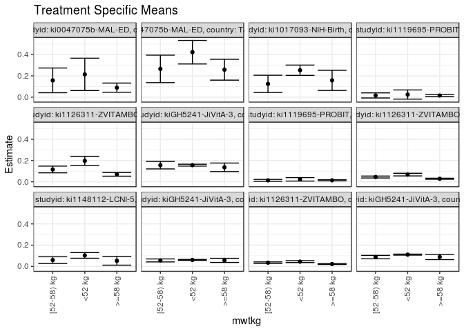

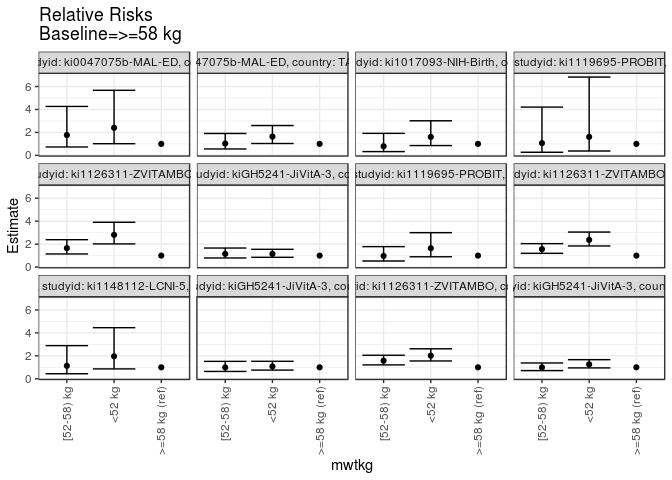

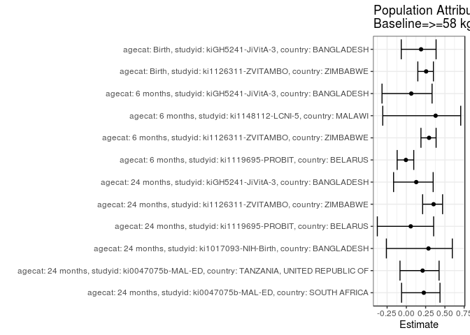

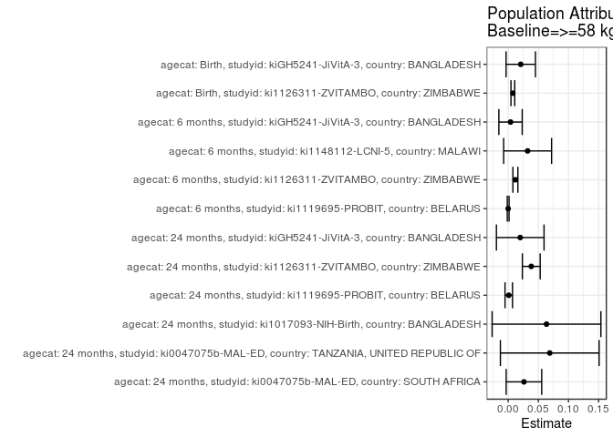

## Results Table

### Parameter: TSM

| agecat | studyid | country | intervention_level | baseline_level | estimate | ci_lower | ci_upper |
| --- | --- | --- | --- | --- | --- | --- | --- |
| Birth | ki1126311-ZVITAMBO | ZIMBABWE | >=58 kg | NA | 0.0222373 | 0.0183905 | 0.0260841 |
| Birth | ki1126311-ZVITAMBO | ZIMBABWE | <52 kg | NA | 0.0448417 | 0.0361621 | 0.0535214 |
| Birth | ki1126311-ZVITAMBO | ZIMBABWE | [52-58) kg | NA | 0.0350871 | 0.0281023 | 0.0420720 |
| Birth | kiGH5241-JiVitA-3 | BANGLADESH | >=58 kg | NA | 0.0882899 | 0.0636098 | 0.1129701 |
| Birth | kiGH5241-JiVitA-3 | BANGLADESH | <52 kg | NA | 0.1109922 | 0.1062855 | 0.1156988 |
| Birth | kiGH5241-JiVitA-3 | BANGLADESH | [52-58) kg | NA | 0.0877230 | 0.0715387 | 0.1039073 |
| 6 months | ki1119695-PROBIT | BELARUS | >=58 kg | NA | 0.0140123 | 0.0091743 | 0.0188502 |
| 6 months | ki1119695-PROBIT | BELARUS | <52 kg | NA | 0.0230112 | 0.0067990 | 0.0392233 |
| 6 months | ki1119695-PROBIT | BELARUS | [52-58) kg | NA | 0.0136090 | 0.0048482 | 0.0223699 |
| 6 months | ki1126311-ZVITAMBO | ZIMBABWE | >=58 kg | NA | 0.0285534 | 0.0235661 | 0.0335407 |
| 6 months | ki1126311-ZVITAMBO | ZIMBABWE | <52 kg | NA | 0.0676677 | 0.0552716 | 0.0800639 |
| 6 months | ki1126311-ZVITAMBO | ZIMBABWE | [52-58) kg | NA | 0.0446457 | 0.0356273 | 0.0536641 |
| 6 months | ki1148112-LCNI-5 | MALAWI | >=58 kg | NA | 0.0526316 | 0.0116170 | 0.0936461 |
| 6 months | ki1148112-LCNI-5 | MALAWI | <52 kg | NA | 0.1031746 | 0.0766021 | 0.1297471 |
| 6 months | ki1148112-LCNI-5 | MALAWI | [52-58) kg | NA | 0.0593607 | 0.0280461 | 0.0906753 |
| 6 months | kiGH5241-JiVitA-3 | BANGLADESH | >=58 kg | NA | 0.0568511 | 0.0374808 | 0.0762214 |
| 6 months | kiGH5241-JiVitA-3 | BANGLADESH | <52 kg | NA | 0.0611532 | 0.0570534 | 0.0652530 |
| 6 months | kiGH5241-JiVitA-3 | BANGLADESH | [52-58) kg | NA | 0.0561594 | 0.0420242 | 0.0702946 |
| 24 months | ki0047075b-MAL-ED | SOUTH AFRICA | >=58 kg | NA | 0.0892857 | 0.0460736 | 0.1324978 |
| 24 months | ki0047075b-MAL-ED | SOUTH AFRICA | <52 kg | NA | 0.2142857 | 0.0619759 | 0.3665956 |
| 24 months | ki0047075b-MAL-ED | SOUTH AFRICA | [52-58) kg | NA | 0.1578947 | 0.0417089 | 0.2740806 |
| 24 months | ki0047075b-MAL-ED | TANZANIA, UNITED REPUBLIC OF | >=58 kg | NA | 0.2581864 | 0.1601829 | 0.3561899 |
| 24 months | ki0047075b-MAL-ED | TANZANIA, UNITED REPUBLIC OF | <52 kg | NA | 0.4230676 | 0.3121331 | 0.5340021 |
| 24 months | ki0047075b-MAL-ED | TANZANIA, UNITED REPUBLIC OF | [52-58) kg | NA | 0.2658642 | 0.1366726 | 0.3950558 |
| 24 months | ki1017093-NIH-Birth | BANGLADESH | >=58 kg | NA | 0.1578947 | 0.0631218 | 0.2526677 |
| 24 months | ki1017093-NIH-Birth | BANGLADESH | <52 kg | NA | 0.2532468 | 0.2046239 | 0.3018696 |
| 24 months | ki1017093-NIH-Birth | BANGLADESH | [52-58) kg | NA | 0.1250000 | 0.0438808 | 0.2061192 |
| 24 months | ki1119695-PROBIT | BELARUS | >=58 kg | NA | 0.0152773 | 0.0048389 | 0.0257157 |
| 24 months | ki1119695-PROBIT | BELARUS | <52 kg | NA | 0.0246154 | -0.0186703 | 0.0679010 |
| 24 months | ki1119695-PROBIT | BELARUS | [52-58) kg | NA | 0.0162482 | -0.0076028 | 0.0400991 |
| 24 months | ki1126311-ZVITAMBO | ZIMBABWE | >=58 kg | NA | 0.0700411 | 0.0527072 | 0.0873750 |
| 24 months | ki1126311-ZVITAMBO | ZIMBABWE | <52 kg | NA | 0.1966780 | 0.1536738 | 0.2396821 |
| 24 months | ki1126311-ZVITAMBO | ZIMBABWE | [52-58) kg | NA | 0.1156931 | 0.0842072 | 0.1471790 |
| 24 months | kiGH5241-JiVitA-3 | BANGLADESH | >=58 kg | NA | 0.1359675 | 0.0957825 | 0.1761526 |
| 24 months | kiGH5241-JiVitA-3 | BANGLADESH | <52 kg | NA | 0.1562231 | 0.1471456 | 0.1653005 |
| 24 months | kiGH5241-JiVitA-3 | BANGLADESH | [52-58) kg | NA | 0.1561658 | 0.1209469 | 0.1913848 |

### Parameter: E(Y)

| agecat | studyid | country | intervention_level | baseline_level | estimate | ci_lower | ci_upper |
| --- | --- | --- | --- | --- | --- | --- | --- |
| Birth | ki1126311-ZVITAMBO | ZIMBABWE | NA | NA | 0.0299157 | 0.0267365 | 0.0330949 |
| Birth | kiGH5241-JiVitA-3 | BANGLADESH | NA | NA | 0.1090852 | 0.1045269 | 0.1136436 |
| 6 months | ki1119695-PROBIT | BELARUS | NA | NA | 0.0139272 | 0.0091775 | 0.0186768 |
| 6 months | ki1126311-ZVITAMBO | ZIMBABWE | NA | NA | 0.0404652 | 0.0362140 | 0.0447164 |
| 6 months | ki1148112-LCNI-5 | MALAWI | NA | NA | 0.0848268 | 0.0659398 | 0.1037138 |
| 6 months | kiGH5241-JiVitA-3 | BANGLADESH | NA | NA | 0.0607071 | 0.0568535 | 0.0645606 |
| 24 months | ki0047075b-MAL-ED | SOUTH AFRICA | NA | NA | 0.1153846 | 0.0743622 | 0.1564070 |
| 24 months | ki0047075b-MAL-ED | TANZANIA, UNITED REPUBLIC OF | NA | NA | 0.3271028 | 0.2640978 | 0.3901078 |
| 24 months | ki1017093-NIH-Birth | BANGLADESH | NA | NA | 0.2214452 | 0.1821080 | 0.2607825 |
| 24 months | ki1119695-PROBIT | BELARUS | NA | NA | 0.0161974 | 0.0032099 | 0.0291848 |
| 24 months | ki1126311-ZVITAMBO | ZIMBABWE | NA | NA | 0.1083123 | 0.0930224 | 0.1236023 |
| 24 months | kiGH5241-JiVitA-3 | BANGLADESH | NA | NA | 0.1559059 | 0.1471753 | 0.1646364 |

### Parameter: RR

| agecat | studyid | country | intervention_level | baseline_level | estimate | ci_lower | ci_upper |
| --- | --- | --- | --- | --- | --- | --- | --- |
| Birth | ki1126311-ZVITAMBO | ZIMBABWE | >=58 kg | >=58 kg | 1.0000000 | 1.0000000 | 1.000000 |
| Birth | ki1126311-ZVITAMBO | ZIMBABWE | <52 kg | >=58 kg | 2.0165102 | 1.5553281 | 2.614441 |
| Birth | ki1126311-ZVITAMBO | ZIMBABWE | [52-58) kg | >=58 kg | 1.5778493 | 1.2120289 | 2.054083 |
| Birth | kiGH5241-JiVitA-3 | BANGLADESH | >=58 kg | >=58 kg | 1.0000000 | 1.0000000 | 1.000000 |
| Birth | kiGH5241-JiVitA-3 | BANGLADESH | <52 kg | >=58 kg | 1.2571326 | 0.9481123 | 1.666873 |
| Birth | kiGH5241-JiVitA-3 | BANGLADESH | [52-58) kg | >=58 kg | 0.9935787 | 0.7148237 | 1.381038 |
| 6 months | ki1119695-PROBIT | BELARUS | >=58 kg | >=58 kg | 1.0000000 | 1.0000000 | 1.000000 |
| 6 months | ki1119695-PROBIT | BELARUS | <52 kg | >=58 kg | 1.6422150 | 0.8988702 | 3.000289 |
| 6 months | ki1119695-PROBIT | BELARUS | [52-58) kg | >=58 kg | 0.9712233 | 0.5296055 | 1.781089 |
| 6 months | ki1126311-ZVITAMBO | ZIMBABWE | >=58 kg | >=58 kg | 1.0000000 | 1.0000000 | 1.000000 |
| 6 months | ki1126311-ZVITAMBO | ZIMBABWE | <52 kg | >=58 kg | 2.3698664 | 1.8398854 | 3.052509 |
| 6 months | ki1126311-ZVITAMBO | ZIMBABWE | [52-58) kg | >=58 kg | 1.5635854 | 1.1971646 | 2.042158 |
| 6 months | ki1148112-LCNI-5 | MALAWI | >=58 kg | >=58 kg | 1.0000000 | 1.0000000 | 1.000000 |
| 6 months | ki1148112-LCNI-5 | MALAWI | <52 kg | >=58 kg | 1.9603175 | 0.8627530 | 4.454166 |
| 6 months | ki1148112-LCNI-5 | MALAWI | [52-58) kg | >=58 kg | 1.1278539 | 0.4401123 | 2.890295 |
| 6 months | kiGH5241-JiVitA-3 | BANGLADESH | >=58 kg | >=58 kg | 1.0000000 | 1.0000000 | 1.000000 |
| 6 months | kiGH5241-JiVitA-3 | BANGLADESH | <52 kg | >=58 kg | 1.0756731 | 0.7591219 | 1.524225 |
| 6 months | kiGH5241-JiVitA-3 | BANGLADESH | [52-58) kg | >=58 kg | 0.9878331 | 0.6422972 | 1.519257 |
| 24 months | ki0047075b-MAL-ED | SOUTH AFRICA | >=58 kg | >=58 kg | 1.0000000 | 1.0000000 | 1.000000 |
| 24 months | ki0047075b-MAL-ED | SOUTH AFRICA | <52 kg | >=58 kg | 2.4000000 | 1.0156837 | 5.671057 |
| 24 months | ki0047075b-MAL-ED | SOUTH AFRICA | [52-58) kg | >=58 kg | 1.7684211 | 0.7329701 | 4.266631 |
| 24 months | ki0047075b-MAL-ED | TANZANIA, UNITED REPUBLIC OF | >=58 kg | >=58 kg | 1.0000000 | 1.0000000 | 1.000000 |
| 24 months | ki0047075b-MAL-ED | TANZANIA, UNITED REPUBLIC OF | <52 kg | >=58 kg | 1.6386129 | 1.0326437 | 2.600173 |
| 24 months | ki0047075b-MAL-ED | TANZANIA, UNITED REPUBLIC OF | [52-58) kg | >=58 kg | 1.0297374 | 0.5555813 | 1.908558 |
| 24 months | ki1017093-NIH-Birth | BANGLADESH | >=58 kg | >=58 kg | 1.0000000 | 1.0000000 | 1.000000 |
| 24 months | ki1017093-NIH-Birth | BANGLADESH | <52 kg | >=58 kg | 1.6038961 | 0.8540608 | 3.012060 |
| 24 months | ki1017093-NIH-Birth | BANGLADESH | [52-58) kg | >=58 kg | 0.7916667 | 0.3270664 | 1.916235 |
| 24 months | ki1119695-PROBIT | BELARUS | >=58 kg | >=58 kg | 1.0000000 | 1.0000000 | 1.000000 |
| 24 months | ki1119695-PROBIT | BELARUS | <52 kg | >=58 kg | 1.6112375 | 0.3803958 | 6.824696 |
| 24 months | ki1119695-PROBIT | BELARUS | [52-58) kg | >=58 kg | 1.0635476 | 0.2689766 | 4.205323 |
| 24 months | ki1126311-ZVITAMBO | ZIMBABWE | >=58 kg | >=58 kg | 1.0000000 | 1.0000000 | 1.000000 |
| 24 months | ki1126311-ZVITAMBO | ZIMBABWE | <52 kg | >=58 kg | 2.8080382 | 2.0191633 | 3.905122 |
| 24 months | ki1126311-ZVITAMBO | ZIMBABWE | [52-58) kg | >=58 kg | 1.6517898 | 1.1435959 | 2.385816 |
| 24 months | kiGH5241-JiVitA-3 | BANGLADESH | >=58 kg | >=58 kg | 1.0000000 | 1.0000000 | 1.000000 |
| 24 months | kiGH5241-JiVitA-3 | BANGLADESH | <52 kg | >=58 kg | 1.1489736 | 0.8529609 | 1.547715 |
| 24 months | kiGH5241-JiVitA-3 | BANGLADESH | [52-58) kg | >=58 kg | 1.1485526 | 0.7952202 | 1.658878 |

### Parameter: PAR

| agecat | studyid | country | intervention_level | baseline_level | estimate | ci_lower | ci_upper |
| --- | --- | --- | --- | --- | --- | --- | --- |
| Birth | ki1126311-ZVITAMBO | ZIMBABWE | >=58 kg | NA | 0.0076784 | 0.0045596 | 0.0107972 |
| Birth | kiGH5241-JiVitA-3 | BANGLADESH | >=58 kg | NA | 0.0207953 | -0.0035636 | 0.0451542 |
| 6 months | ki1119695-PROBIT | BELARUS | >=58 kg | NA | -0.0000851 | -0.0015783 | 0.0014081 |
| 6 months | ki1126311-ZVITAMBO | ZIMBABWE | >=58 kg | NA | 0.0119118 | 0.0077619 | 0.0160618 |
| 6 months | ki1148112-LCNI-5 | MALAWI | >=58 kg | NA | 0.0321952 | -0.0075626 | 0.0719530 |
| 6 months | kiGH5241-JiVitA-3 | BANGLADESH | >=58 kg | NA | 0.0038560 | -0.0155076 | 0.0232195 |
| 24 months | ki0047075b-MAL-ED | SOUTH AFRICA | >=58 kg | NA | 0.0260989 | -0.0033781 | 0.0555759 |
| 24 months | ki0047075b-MAL-ED | TANZANIA, UNITED REPUBLIC OF | >=58 kg | NA | 0.0689164 | -0.0129717 | 0.1508045 |
| 24 months | ki1017093-NIH-Birth | BANGLADESH | >=58 kg | NA | 0.0635505 | -0.0266855 | 0.1537865 |
| 24 months | ki1119695-PROBIT | BELARUS | >=58 kg | NA | 0.0009200 | -0.0052791 | 0.0071192 |
| 24 months | ki1126311-ZVITAMBO | ZIMBABWE | >=58 kg | NA | 0.0382713 | 0.0234950 | 0.0530475 |
| 24 months | kiGH5241-JiVitA-3 | BANGLADESH | >=58 kg | NA | 0.0199384 | -0.0195724 | 0.0594491 |

### Parameter: PAF

| agecat | studyid | country | intervention_level | baseline_level | estimate | ci_lower | ci_upper |
| --- | --- | --- | --- | --- | --- | --- | --- |
| Birth | ki1126311-ZVITAMBO | ZIMBABWE | >=58 kg | NA | 0.2566677 | 0.1486696 | 0.3509654 |
| Birth | kiGH5241-JiVitA-3 | BANGLADESH | >=58 kg | NA | 0.1906334 | -0.0664616 | 0.3857498 |
| 6 months | ki1119695-PROBIT | BELARUS | >=58 kg | NA | -0.0061116 | -0.1194976 | 0.0957903 |
| 6 months | ki1126311-ZVITAMBO | ZIMBABWE | >=58 kg | NA | 0.2943721 | 0.1892605 | 0.3858561 |
| 6 months | ki1148112-LCNI-5 | MALAWI | >=58 kg | NA | 0.3795404 | -0.3062459 | 0.7052851 |
| 6 months | kiGH5241-JiVitA-3 | BANGLADESH | >=58 kg | NA | 0.0635173 | -0.3159819 | 0.3335776 |
| 24 months | ki0047075b-MAL-ED | SOUTH AFRICA | >=58 kg | NA | 0.2261905 | -0.0622499 | 0.4363086 |
| 24 months | ki0047075b-MAL-ED | TANZANIA, UNITED REPUBLIC OF | >=58 kg | NA | 0.2106872 | -0.0826423 | 0.4245425 |
| 24 months | ki1017093-NIH-Birth | BANGLADESH | >=58 kg | NA | 0.2869806 | -0.2593344 | 0.5962973 |
| 24 months | ki1119695-PROBIT | BELARUS | >=58 kg | NA | 0.0568020 | -0.3768638 | 0.3538776 |
| 24 months | ki1126311-ZVITAMBO | ZIMBABWE | >=58 kg | NA | 0.3533419 | 0.2110941 | 0.4699409 |
| 24 months | kiGH5241-JiVitA-3 | BANGLADESH | >=58 kg | NA | 0.1278872 | -0.1660260 | 0.3477155 |